# Homework 1: Linear Regression

Vijay Penmetsa

There are six questions (30 total points) in this assignment. The minimum increment is 1 point. Please type in your answers directly in the R Markdown file. After completion, **successfully** knitr it as an html file. Submit **both** the html file and the R Markdown file via Canvas. Please name the R Markdown file in the following format: LastName_FirstName_HW1.Rmd, e.g. Zhao_Zifeng_HW1.Rmd.

## Used Car Dataset [12 points]

The used car dataset is the one we analyzed in class. Let’s read in the data stored in `UsedCar.csv`.

```r
total_data <- read.csv("./UsedCar.csv", header=T, stringsAsFactors=T)
```

### **Q1 [2 points]**

Since the dependent variable `Price` is severely right-skewed, create a log-transformation of `Price` and store it as a new variable named `Log_price` in the data.frame `total_data`.

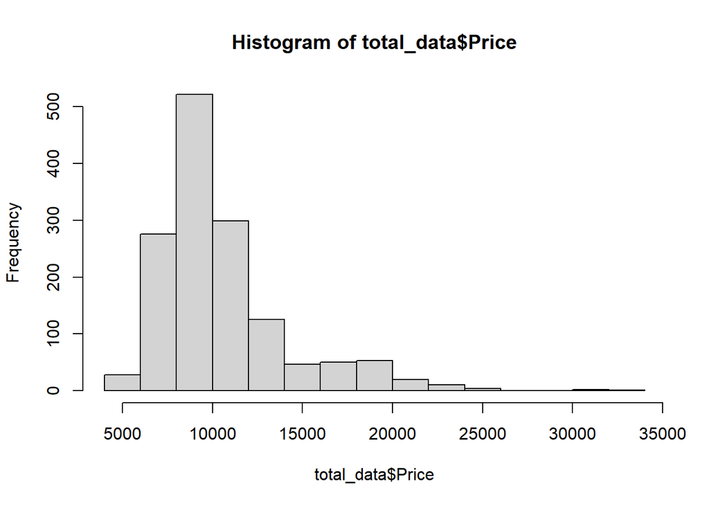

```r
## Write code solution to Q1 here
hist(total_data$Price)
```

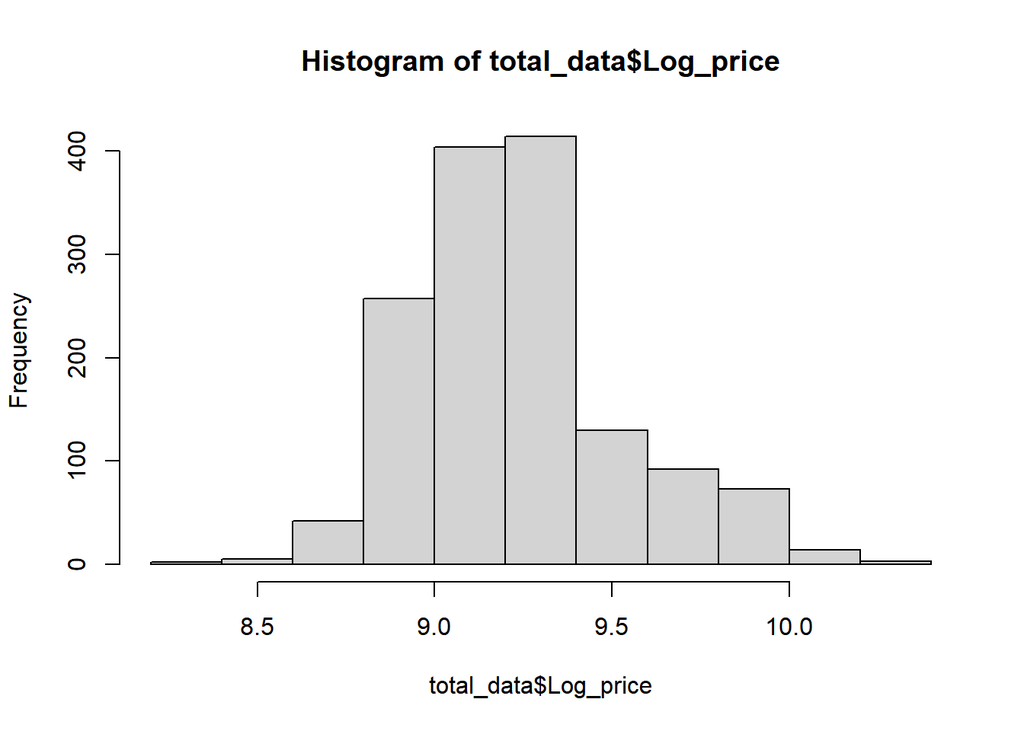

```r
total_data$Log_price <- log(total_data$Price + 1)
hist(total_data$Log_price)
```

### **Q2 [6 points]**

Fit a linear regression model of Log_price w.r.t. two predictors Age and Mileage, name it `lm_short`.

```r
## Fit the lm_short model here
lm_short <- lm(Log_price~Age+
                Mileage
              , data=total_data)
summary(lm_short)
```

```
##
## Call:
## lm(formula = Log_price ~ Age + Mileage, data = total_data)
##
## Residuals:
##      Min       1Q   Median       3Q      Max
## -0.84324 -0.08037  0.00043  0.07970  0.49794
##
## Coefficients:
##               Estimate Std. Error t value Pr(>|t|)
## (Intercept)  1.004e+01  1.101e-02  911.69   <2e-16 ***
## Age         -1.217e-02  2.151e-04  -56.58   <2e-16 ***
## Mileage     -1.757e-06  1.067e-07  -16.48   <2e-16 ***
## ---
## Signif. codes:  0 '***' 0.001 '**' 0.01 '*' 0.05 '.' 0.1 ' ' 1
##
## Residual standard error: 0.1307 on 1433 degrees of freedom
## Multiple R-squared:  0.8055, Adjusted R-squared:  0.8052
## F-statistic:  2967 on 2 and 1433 DF,  p-value: < 2.2e-16
```

**Q2(a) [2 points]** What is the $R^2$ of `lm_short`? What are the (in-sample) MAE and RMSE of `lm_short`?

```r
## Write code solution to Q2(a) here
summary(lm_short)
```

```
##
## Call:
## lm(formula = Log_price ~ Age + Mileage, data = total_data)
##
## Residuals:
##      Min       1Q   Median       3Q      Max
## -0.84324 -0.08037  0.00043  0.07970  0.49794
##
## Coefficients:
##               Estimate Std. Error t value Pr(>|t|)
## (Intercept)  1.004e+01  1.101e-02  911.69   <2e-16 ***
## Age         -1.217e-02  2.151e-04  -56.58   <2e-16 ***
## Mileage     -1.757e-06  1.067e-07  -16.48   <2e-16 ***
## ---
## Signif. codes:  0 '***' 0.001 '**' 0.01 '*' 0.05 '.' 0.1 ' ' 1
##
## Residual standard error: 0.1307 on 1433 degrees of freedom
## Multiple R-squared:  0.8055, Adjusted R-squared:  0.8052
## F-statistic:  2967 on 2 and 1433 DF,  p-value: < 2.2e-16
```

```r
error <- lm_short$residuals
mae <- mean(abs(error))
mae
```

```
## [1] 0.09850018
```

```r
rmse <- sqrt(mean(error ^ 2))
rmse
```

```
## [1] 0.1305951
```

Answer:  
R-squared = 0.8055  
MAE = 0.09850018  
RMSE = 0.1305951

**Q2(b) [1 point]** What is the estimated coefficient of `lm_short` for Age and Mileage?

```r
## Write code solution to Q2(b) here
lm_short$coefficients
```

```
##   (Intercept)           Age       Mileage
##  1.003508e+01 -1.216931e-02 -1.757371e-06
```

**Q2(c) [3 points]** How should we interpret the estimated coefficient of Age at the log-scale and the original scale of Price?

```r
age_coeff_log <- lm_short$coefficients[2]
exp(age_coeff_log) - 1
```

```
##         Age
## -0.01209556
```

Answer:  
At log scale of price: As age increases by a year the log of price decreases by 1.216 percent.  
At original scale of price: As age increases by a year the price decreases by 1.209 percent.

### **Q3 [4 points]**

We read in new data in `UsedCar_Newdata.csv` and store it in `new_cars`, which contains 5 used cars that need to be priced.

```r
new_cars <- read.csv('./UsedCar_Newdata.csv', header=T, stringsAsFactors=T)
```

**Q3(a) [2 points]** Predict the `new_cars` price at the **original scale** based on the estimated linear regression `lm_short` and further construct a 90% prediction interval.

```r
## Write code solution to Q3(a) here
```

**Q3(b) [2 points]** Based on the prediction in Q3(a), which car has the highest predicted resale value? What is it?

## Car Seat Sales Dataset [18 points]

The car seat sales dataset contains sales of child car seats at 400 different stores and the data is stored in `Carseats.csv`. It contains 9 variables, `Sales`, `CompPrice`, `Income`, `Advertising`, `Population`, `Price`, `ShelveLoc`, `Age` and `Urban`. We would like to build a linear regression model to predict `Sales` at a planned new store. The data description is as follows.

- `Sales`: Unit sales (in thousands) at each location
- `CompPrice`: Price charged by competitor at each location
- `Income`: Community income level (in thousands of dollars)
- `Advertising`: Local advertising budget for company at each location (in thousands of dollars)
- `Population`: Population size in region (in thousands)
- `Price`: Price company charges for car seats at each site
- `ShelveLoc`: A factor with levels Bad, Good and Medium indicating the quality of the shelving location for the car seats at each site
- `Age`: Average age of the local population
- `Urban`: A factor with levels No and Yes to indicate whether the store is in an urban or rural location

### **Q4 [2 points]**

Which variable is the dependent variable? Which predictors are categorical variables?

Answer:  
Dependent variable = Sales  
Categorical predictors = ShelveLoc, Urban

### **Q5 [8 points]**

Let’s read in the data and perform visualization to get a better sense of the data.

**Q5(a) [2 points]** Correctly read in the data stored at `Carseats.csv`.

```r
## Write code solution to Q5(a) here
car_seats <- read.csv('./Carseats.csv', header=T, stringsAsFactors=T)
```

**Q5(b) [2 points]** Produce a scatterplot between `Sales` and `Price`. What is the general pattern from the scatterplot?

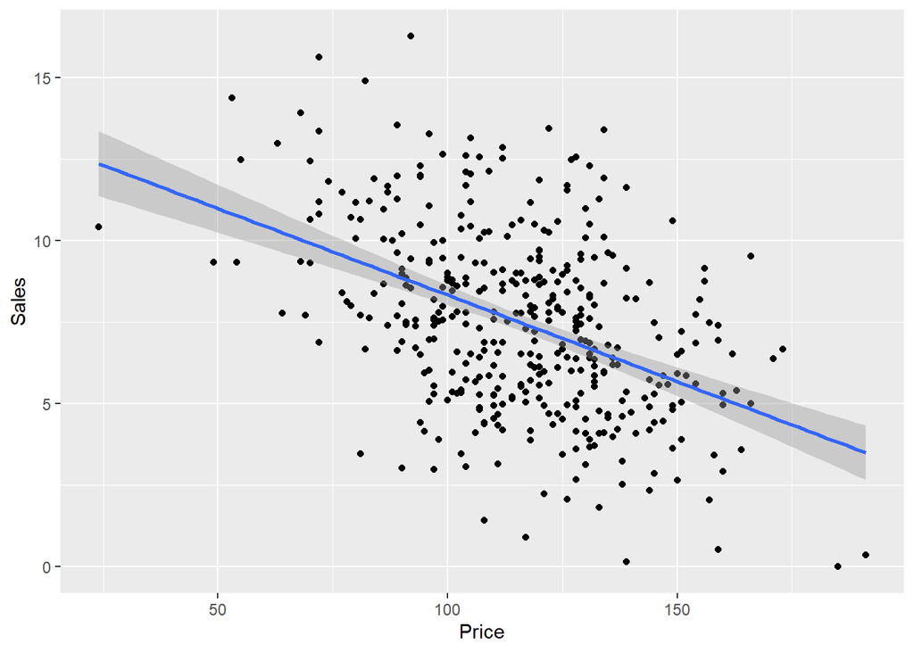

```r
## Write code solution to Q5(b) here
library(ggplot2)
ggplot(car_seats, aes(x = Price, y = Sales)) +
  geom_point() +
  geom_smooth(formula = y~x, method = lm)
```

Answer:  
As seat price increases, amount of seats sold decreases

**Q5(c) [2 points]** Produce a boxplot between `Sales` and `ShelveLoc`. What is the general pattern from the boxplot?

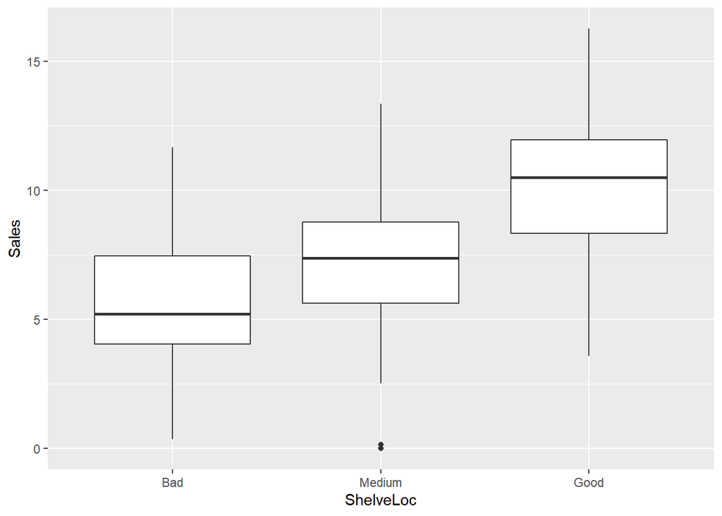

```r
## Write code solution to Q5(c) here
car_seats$ShelveLoc <- factor(car_seats$ShelveLoc , levels=c("Bad", "Medium", "Good"))
ggplot(car_seats, aes(x = ShelveLoc, y = Sales)) + geom_boxplot()
```

Answer:  
On average, better shelf location leads to better sales

**Q5(d) [2 points]** Produce a histogram of `Sales`. Is `Sales` severely right-skewed?

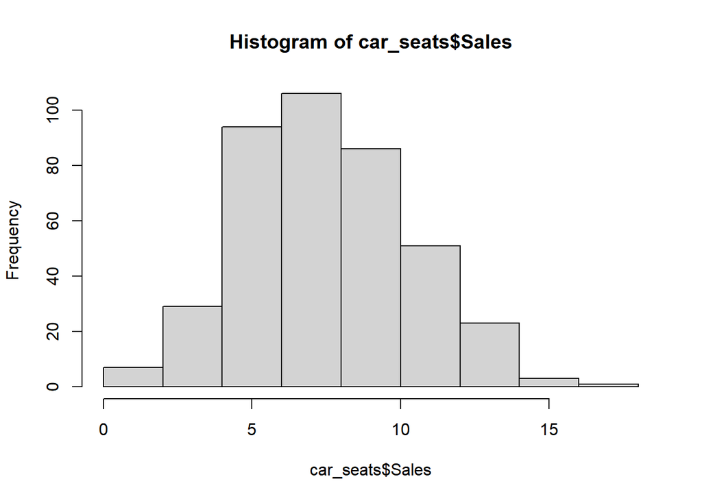

```r
## Write code solution to Q5(d) here
hist(car_seats$Sales)
```

Answer:  
No. Sales is not severely right skewed.

### **Q6 [8 points]**

**Q6(a) [2 points]** Fit a linear regression model of `Sales` w.r.t. all the predictors available in the dataset, name it `lm_full`. Take a look at the summary of `lm_full`.

```r
## Write code solution to Q6(a) here

lm_full <- lm(Sales ~ CompPrice
              + Income
              + Advertising
              + Population
              + Price
              + ShelveLoc
              + Age
              + Urban
              , data = car_seats)
summary(lm_full)
```

```
##
## Call:
## lm(formula = Sales ~ CompPrice + Income + Advertising + Population +
##     Price + ShelveLoc + Age + Urban, data = car_seats)
##
## Residuals:
##     Min      1Q  Median      3Q     Max
## -2.7868 -0.6988  0.0160  0.6786  3.2736
##
## Coefficients:
##                   Estimate Std. Error t value Pr(>|t|)
## (Intercept)      5.3037420  0.5263440  10.077  < 2e-16 ***
## CompPrice        0.0926753  0.0041490  22.337  < 2e-16 ***
## Income           0.0157694  0.0018400   8.570 2.44e-16 ***
## Advertising      0.1136057  0.0080241  14.158  < 2e-16 ***
## Population       0.0003255  0.0003627   0.897    0.370
## Price           -0.0954335  0.0026720 -35.716  < 2e-16 ***
## ShelveLocMedium  1.9681961  0.1259228  15.630  < 2e-16 ***
## ShelveLocGood    4.8538486  0.1530955  31.705  < 2e-16 ***
## Age             -0.0461324  0.0031829 -14.494  < 2e-16 ***
## UrbanYes         0.1268438  0.1129471   1.123    0.262
## ---
## Signif. codes:  0 '***' 0.001 '**' 0.01 '*' 0.05 '.' 0.1 ' ' 1
##
## Residual standard error: 1.02 on 390 degrees of freedom
## Multiple R-squared:  0.8726, Adjusted R-squared:  0.8697
## F-statistic: 296.9 on 9 and 390 DF,  p-value: < 2.2e-16
```

**Q6(b) [2 points]** What is the estimated coefficient of `lm_full` for CompPrice and Price? How should we interpret the estimated coefficients?

```r
## Write code solution to Q6(b) here
lm_full$coefficients
```

```
##     (Intercept)       CompPrice          Income     Advertising      Population
##    5.3037419949    0.0926752906    0.0157693826    0.1136056503    0.0003254507
##           Price ShelveLocMedium   ShelveLocGood             Age        UrbanYes
##   -0.0954334977    1.9681961372    4.8538485985   -0.0461324381    0.1268438370
```

Answer:  
Estimated coefficient for CompPrice = 0.0926752906  
Estimated coefficient for Price = -0.0954334977

**Q6(c) [2 points]** Which predictor(s) are not statistically significant in the model?

Answer:  
Population and UrbanYes are not statistically significant because of high p-values.

**Q6(d) [2 points]** What is the $R^2$ of `lm_full`? What are the (in-sample) MAE and RMSE of `lm_full`?

```r
## Write code solution to Q6(d) here
summary(lm_full)
```

```
##
## Call:
## lm(formula = Sales ~ CompPrice + Income + Advertising + Population +
##     Price + ShelveLoc + Age + Urban, data = car_seats)
##
## Residuals:
##     Min      1Q  Median      3Q     Max
## -2.7868 -0.6988  0.0160  0.6786  3.2736
##
## Coefficients:
##                   Estimate Std. Error t value Pr(>|t|)
## (Intercept)      5.3037420  0.5263440  10.077  < 2e-16 ***
## CompPrice        0.0926753  0.0041490  22.337  < 2e-16 ***
## Income           0.0157694  0.0018400   8.570 2.44e-16 ***
## Advertising      0.1136057  0.0080241  14.158  < 2e-16 ***
## Population       0.0003255  0.0003627   0.897    0.370
## Price           -0.0954335  0.0026720 -35.716  < 2e-16 ***
## ShelveLocMedium  1.9681961  0.1259228  15.630  < 2e-16 ***
## ShelveLocGood    4.8538486  0.1530955  31.705  < 2e-16 ***
## Age             -0.0461324  0.0031829 -14.494  < 2e-16 ***
## UrbanYes         0.1268438  0.1129471   1.123    0.262
## ---
## Signif. codes:  0 '***' 0.001 '**' 0.01 '*' 0.05 '.' 0.1 ' ' 1
##
## Residual standard error: 1.02 on 390 degrees of freedom
## Multiple R-squared:  0.8726, Adjusted R-squared:  0.8697
## F-statistic: 296.9 on 9 and 390 DF,  p-value: < 2.2e-16
```

```r
error_full <- lm_full$residuals
mae <- mean(abs(error_full))
mae
```

```
## [1] 0.805898
```

```r
rmse <- sqrt(mean(error_full ^ 2))
rmse
```

```
## [1] 1.006678
```

Answer:  
R-squared = 0.8726  
MAE = 0.805898  
RMSE = 1.006678